# Deep Hedging a European Call

A reproducible Phase 1 demonstration of dynamic hedging under proportional transaction costs. All reported P&L is discounted, after costs, and includes the initial reporting premium.

```python
from pathlib import Path
import json
import numpy as np
import pandas as pd
import matplotlib.pyplot as plt
from IPython.display import Markdown, display
from deep_hedge_price.config import load_config
from deep_hedge_price.experiments import load_artifact_manifest
from deep_hedge_price.plotting import *
from deep_hedge_price.policy import architecture_rows
from deep_hedge_price.training import checkpoint_directory, load_policy
project_root = Path.cwd()
config = load_config(project_root / 'configs' / 'quick.yaml')
manifest = load_artifact_manifest(config, project_root)
summary_payload = json.loads(manifest['summary_metrics'].read_text())
sanity = json.loads(manifest['sanity_checks'].read_text())
main_results = pd.read_csv(manifest['main_path_results'])
strategy_summary = pd.read_csv(manifest['strategy_summary'], index_col=0)
sensitivity = pd.read_csv(manifest['sensitivity_summary'])
risk_comparison = pd.read_csv(manifest['risk_objective_summary'])
policy_surface = pd.read_csv(manifest['policy_surface'])
trade_scatter = pd.read_csv(manifest['trade_scatter'])
print(f'Loaded {len(main_results):,} path-strategy rows from config {config.fingerprint()}')
```

```
Loaded 80,000 path-strategy rows from config 9db17eb0cb6b
```

## Executive summary

```python
n = strategy_summary.loc['neural_mse']
nh = strategy_summary.loc['no_hedge']
reduction = 1 - n['std_discounted_pnl_after_costs_including_premium'] / nh['std_discounted_pnl_after_costs_including_premium']
warnings = [name for name, value in sanity.items() if isinstance(value, dict) and not value.get('passed', True)]
display(Markdown(f'''- **Out-of-sample comparison:** {config.training.test_paths:,} common paths.
- **Dispersion:** neural hedging changed P&L standard deviation by {reduction:.1%} relative to no hedge.
- **Tail loss:** neural 99% CVaR loss is {n['cvar_loss_99']:.3f}.
- **Sanity checks:** {'all passed' if not warnings else 'warnings: ' + ', '.join(warnings)}.

Claims below follow the generated metrics; a warning is treated as a limitation, not hidden.'''))
```

- **Out-of-sample comparison:** 20,000 common paths.

- **Dispersion:** neural hedging changed P&L standard deviation by 82.9% relative to no hedge.

- **Tail loss:** neural 99% CVaR loss is 2.046.

- **Sanity checks:** all passed.

Claims below follow the generated metrics; a warning is treated as a limitation, not hidden.

## Financial setup and sign convention

Under the physical measure, $S_{t+\Delta t}=S_t\exp[(\mu-\sigma^2/2)\Delta t+\sigma\sqrt{\Delta t}Z_t]$. For a short call, discounted loss excluding premium is

$$L_T=\widetilde H-\sum_t\delta_t(\widetilde S_{t+1}-\widetilde S_t)+\sum_t e^{-rt}\lambda S_t|\delta_t-\delta_{t-1}|.$$

Economic P&L is the Black–Scholes premium minus this loss. The initial position is zero and the specified convention has no terminal liquidation charge.

### Differentiable training path

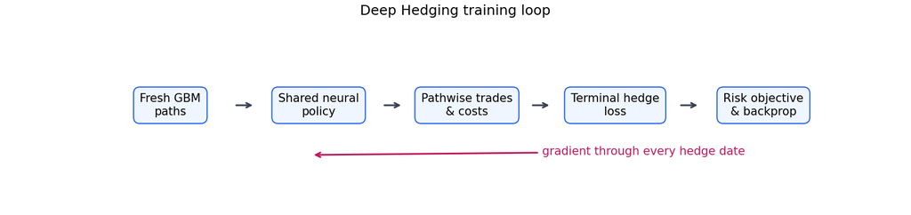

```python
show_figure(training_diagram())
```

## Configuration

```python
config_rows = []
for section, values in config.to_dict().items():
    if isinstance(values, dict):
        config_rows.extend({'section': section, 'parameter': k, 'value': v} for k, v in values.items())
display(pd.DataFrame(config_rows).head(40))
```

|  | section | parameter | value |
| --- | --- | --- | --- |
| 0 | market | seed | 1210 |
| 1 | market | s0 | 100.0 |
| 2 | market | strike | 100.0 |
| 3 | market | maturity_years | 0.119048 |
| 4 | market | n_steps | 30 |
| 5 | market | mu | 0.05 |
| 6 | market | risk_free_rate | 0.0 |
| 7 | market | volatility | 0.2 |
| 8 | market | transaction_cost_bps | 5.0 |
| 9 | market | option_position | -1.0 |
| 10 | market | antithetic_sampling | True |
| 11 | market | reporting_premium | None |
| 12 | policy | hidden_layers | 3 |
| 13 | policy | hidden_units | 64 |
| 14 | policy | activation | silu |
| 15 | policy | layer_norm | False |
| 16 | policy | action_min | -0.25 |
| 17 | policy | action_max | 1.25 |
| 18 | risk | objective | mse |
| 19 | risk | entropic_gamma | 10.0 |
| 20 | risk | cvar_alpha | 0.95 |
| 21 | training | device | cpu |
| 22 | training | batch_size | 2048 |
| 23 | training | epochs | 75 |
| 24 | training | learning_rate | 0.001 |
| 25 | training | weight_decay | 0.000001 |
| 26 | training | gradient_clip_norm | 5.0 |
| 27 | training | validation_paths | 10000 |
| 28 | training | test_paths | 20000 |
| 29 | training | early_stopping_patience | 15 |
| 30 | training | scheduler | reduce_on_plateau |
| 31 | training | evaluation_chunk_size | 4096 |
| 32 | training | deterministic | True |
| 33 | experiment | transaction_cost_grid_bps | (0.0, 1.0, 5.0, 10.0, 25.0) |
| 34 | experiment | no_trade_band | 0.05 |
| 35 | experiment | meaningful_trade_threshold | 0.001 |
| 36 | experiment | run_entropic | True |
| 37 | output | artifacts_dir | artifacts |
| 38 | output | reports_dir | reports |

## Market simulation and payoff

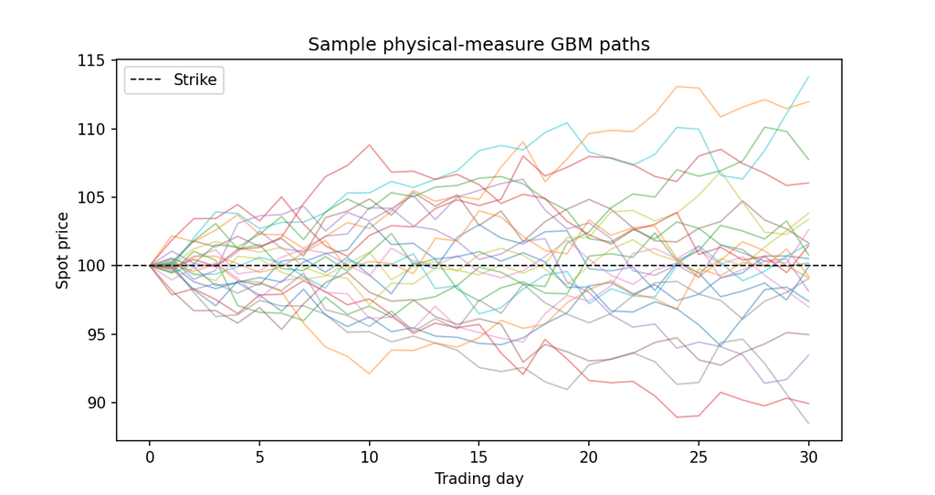

```python
show_figure(sample_paths_figure(config))
```

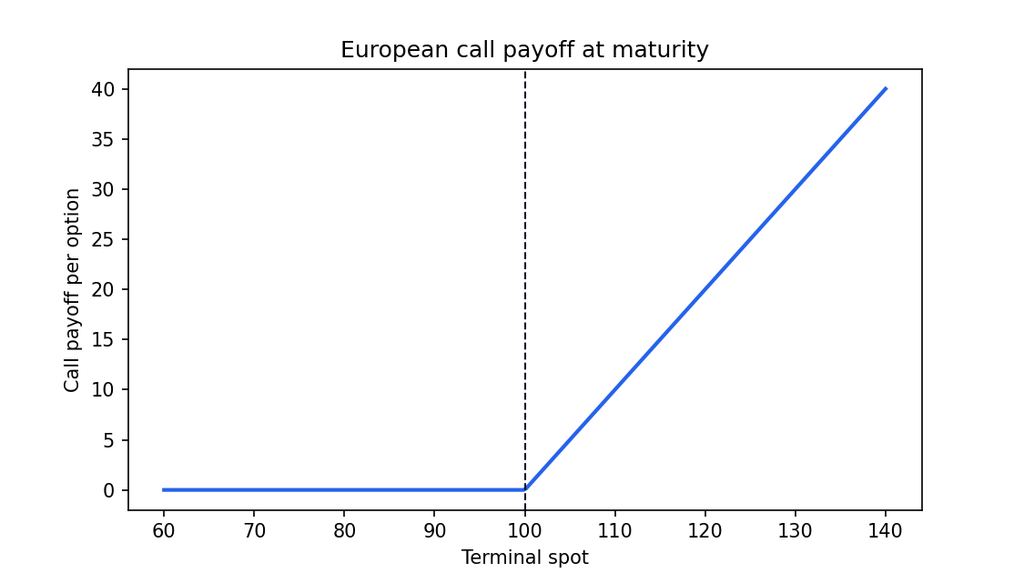

```python
show_figure(payoff_figure(config))
```

## Neural-policy architecture

```python
model_config = config.with_risk(objective='mse')
policy, _ = load_policy(model_config, checkpoint_directory(model_config, project_root) / 'best.pt', device='cpu')
display(pd.DataFrame(architecture_rows(policy)))
print(f'Total trainable parameters: {policy.parameter_count:,}')
```

|  | index | layer | parameters |
| --- | --- | --- | --- |
| 0 | 0 | Linear | 384 |
| 1 | 1 | SiLU | 0 |
| 2 | 2 | Linear | 4160 |
| 3 | 3 | SiLU | 0 |
| 4 | 4 | Linear | 4160 |
| 5 | 5 | SiLU | 0 |
| 6 | 6 | Linear | 65 |

```
Total trainable parameters: 8,769
```

## End-to-end training history

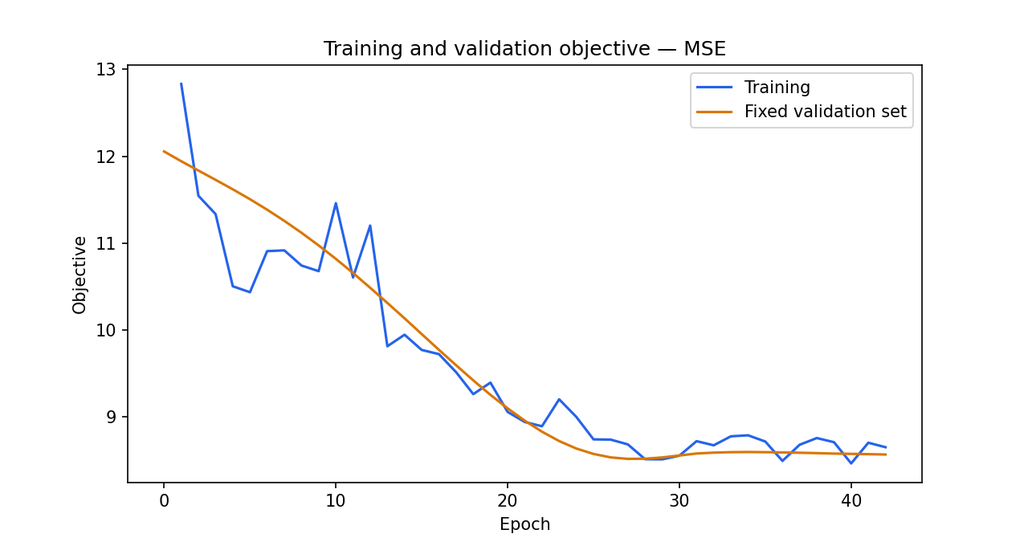

```python
history = pd.read_csv(checkpoint_directory(model_config, project_root) / 'history.csv')
show_figure(training_history_figure(history))
```

## Main comparison on common test paths

```python
comparison_columns = ['mean_discounted_pnl_after_costs_including_premium', 'std_discounted_pnl_after_costs_including_premium', 'rmse_discounted_hedging_error', 'cvar_loss_99', 'average_turnover_shares', 'average_discounted_transaction_cost']
display(strategy_summary[comparison_columns].round(4))
```

|  | mean_discounted_pnl_after_costs_including_premium | std_discounted_pnl_after_costs_including_premium | rmse_discounted_hedging_error | cvar_loss_99 | average_turnover_shares | average_discounted_transaction_cost |
| --- | --- | --- | --- | --- | --- | --- |
| neural_mse | -0.0741 | 0.7417 | 0.7454 | 2.0457 | 2.0608 | 0.1034 |
| black_scholes_delta | -0.1061 | 0.4418 | 0.4543 | 1.6743 | 2.2328 | 0.1117 |
| black_scholes_band | -0.0664 | 0.5349 | 0.5390 | 1.6580 | 1.4283 | 0.0715 |
| no_hedge | -0.2668 | 4.3494 | 4.3575 | 17.5672 | 0.0000 | 0.0000 |

### P&L distributions

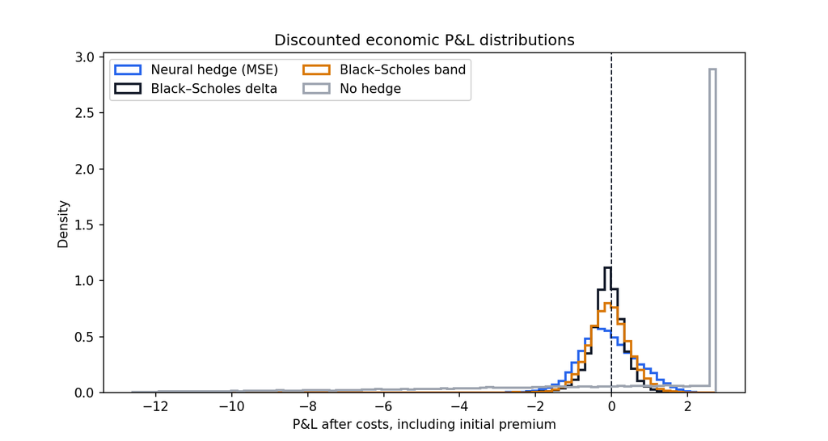

```python
show_figure(pnl_distribution_figure(main_results))
```

### Empirical CDF and lower tail

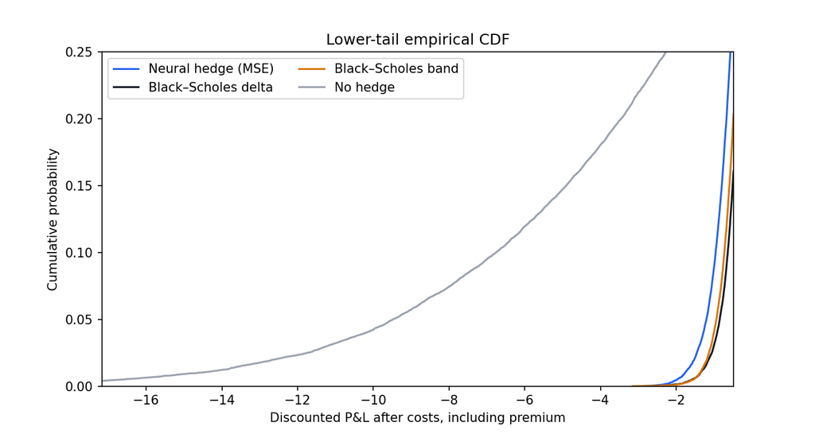

```python
show_figure(ecdf_figure(main_results))
```

### VaR and CVaR

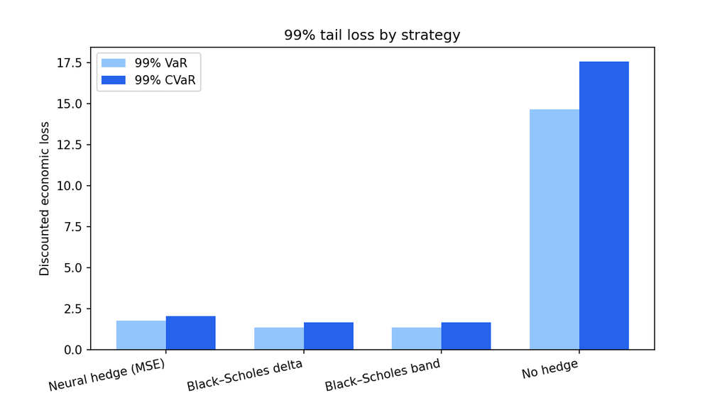

```python
show_figure(var_cvar_figure(strategy_summary))
```

### Turnover and transaction cost

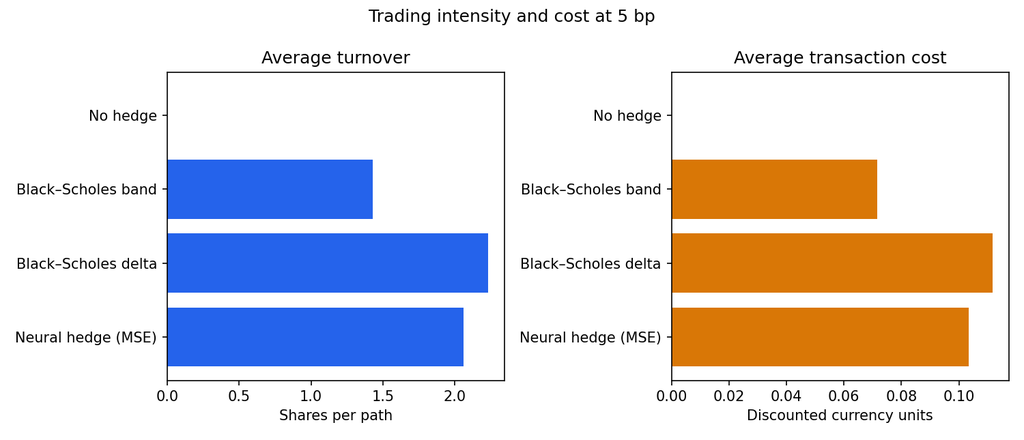

```python
show_figure(turnover_cost_figure(strategy_summary))
```

## Policy surface

The following slice fixes the previous position at 0.5 shares.

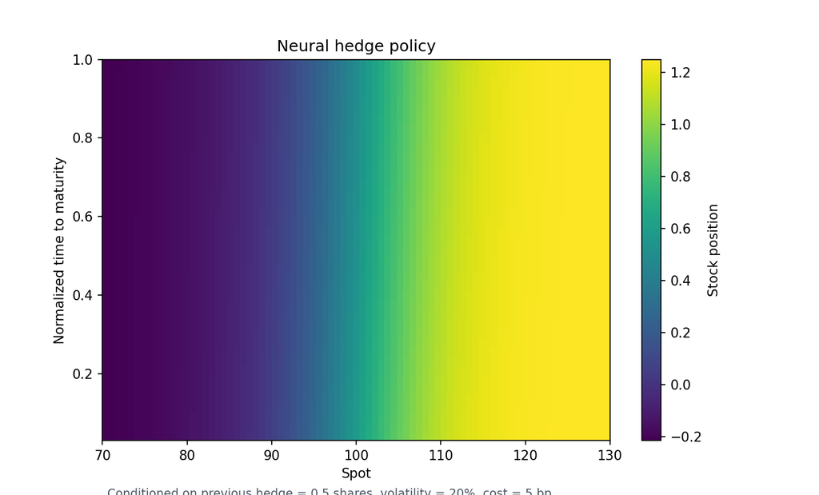

```python
show_figure(policy_heatmap_figure(policy_surface))
```

### Neural minus Black–Scholes delta

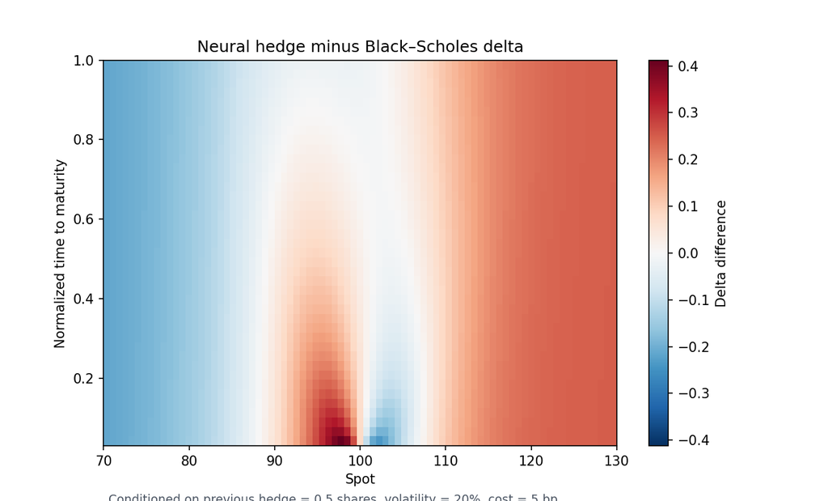

```python
show_figure(policy_heatmap_figure(policy_surface, difference=True))
```

### Policy slices at several maturities

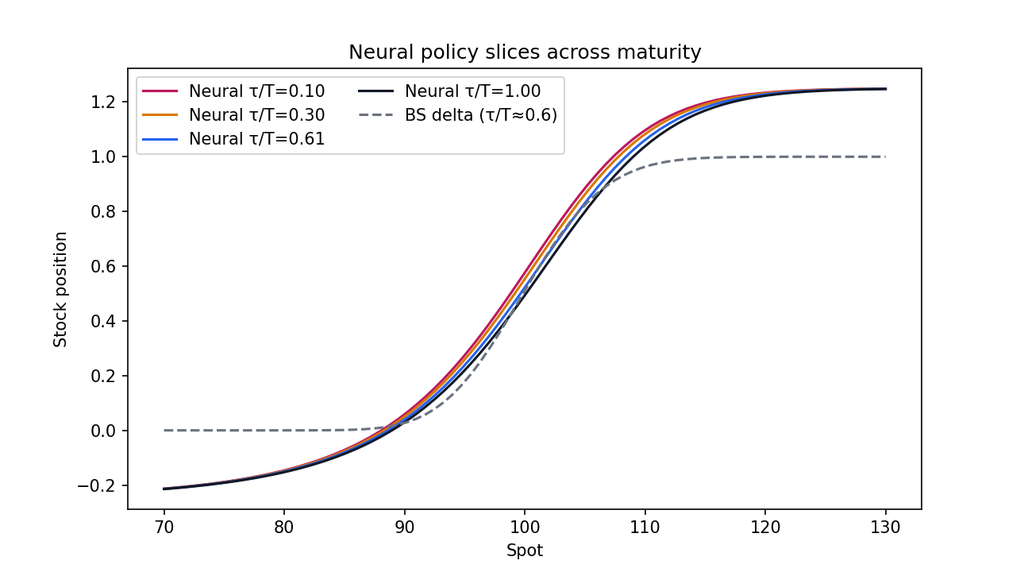

```python
show_figure(policy_slices_figure(policy_surface))
```

### Trade size conditional on prior position and BS target

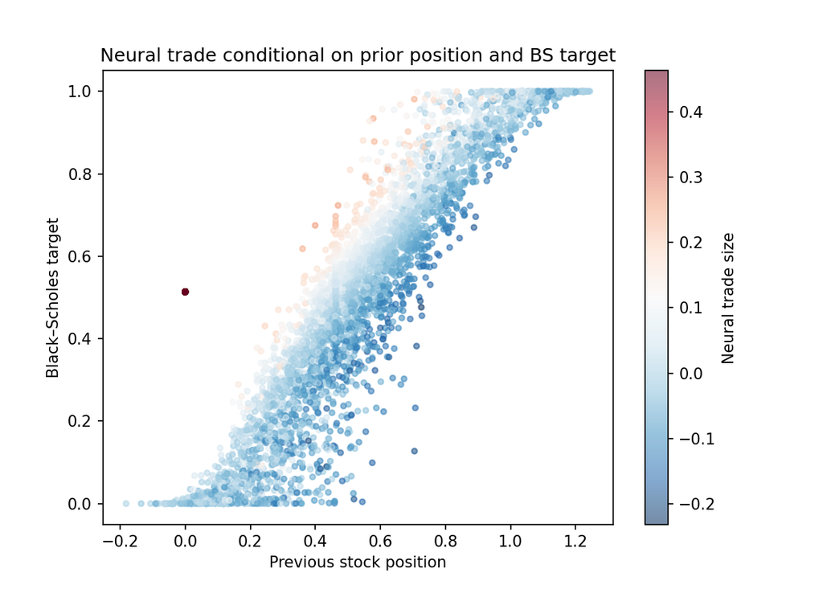

```python
show_figure(trade_scatter_figure(trade_scatter))
```

## Transaction-cost sensitivity

|  | transaction_cost_bps | n_paths | mean_discounted_pnl_after_costs_including_premium | std_discounted_pnl_after_costs_including_premium | rmse_discounted_hedging_error | mae_discounted_hedging_error | median_discounted_pnl | minimum_discounted_pnl | maximum_discounted_pnl | pnl_quantile_01 | ... | terminal_delta_std | terminal_delta_min | terminal_delta_q05 | terminal_delta_median | terminal_delta_q95 | terminal_delta_max | payoff_net_gain_correlation | policy_bs_mae | policy_bs_rmse | checkpoint |
| --- | --- | --- | --- | --- | --- | --- | --- | --- | --- | --- | --- | --- | --- | --- | --- | --- | --- | --- | --- | --- | --- |
| 0 | 0.0 | 20000 | 0.0249 | 0.7305 | 0.7310 | 0.5600 | -0.0040 | -3.3286 | 5.2921 | -1.7252 | ... | 0.3920 | -0.2142 | -0.0157 | 0.6282 | 1.1919 | 1.2498 | 0.9881 | 0.0607 | 0.0854 | /home/kazumasa/projects/deep_hedge_price/artif... |
| 1 | 1.0 | 20000 | 0.0038 | 0.7286 | 0.7286 | 0.5617 | -0.0320 | -3.2936 | 5.1763 | -1.7300 | ... | 0.3864 | -0.2115 | -0.0068 | 0.6265 | 1.1885 | 1.2498 | 0.9879 | 0.0591 | 0.0851 | /home/kazumasa/projects/deep_hedge_price/artif... |
| 2 | 5.0 | 20000 | -0.0741 | 0.7417 | 0.7454 | 0.5932 | -0.1271 | -3.1450 | 4.7311 | -1.7657 | ... | 0.3632 | -0.1956 | 0.0338 | 0.6198 | 1.1744 | 1.2497 | 0.9865 | 0.0569 | 0.0882 | /home/kazumasa/projects/deep_hedge_price/artif... |
| 3 | 10.0 | 20000 | -0.1777 | 0.7458 | 0.7666 | 0.6228 | -0.2452 | -3.1426 | 4.5820 | -1.8184 | ... | 0.3584 | -0.1833 | 0.0472 | 0.6079 | 1.1749 | 1.2498 | 0.9860 | 0.0563 | 0.0884 | /home/kazumasa/projects/deep_hedge_price/artif... |
| 4 | 25.0 | 20000 | -0.2768 | 0.9183 | 0.9591 | 0.7708 | -0.3017 | -4.5141 | 2.5213 | -2.4582 | ... | 0.3674 | -0.0559 | 0.0511 | 0.5495 | 1.1251 | 1.2308 | 0.9775 | 0.0916 | 0.1156 | /home/kazumasa/projects/deep_hedge_price/artif... |

5 rows × 33 columns

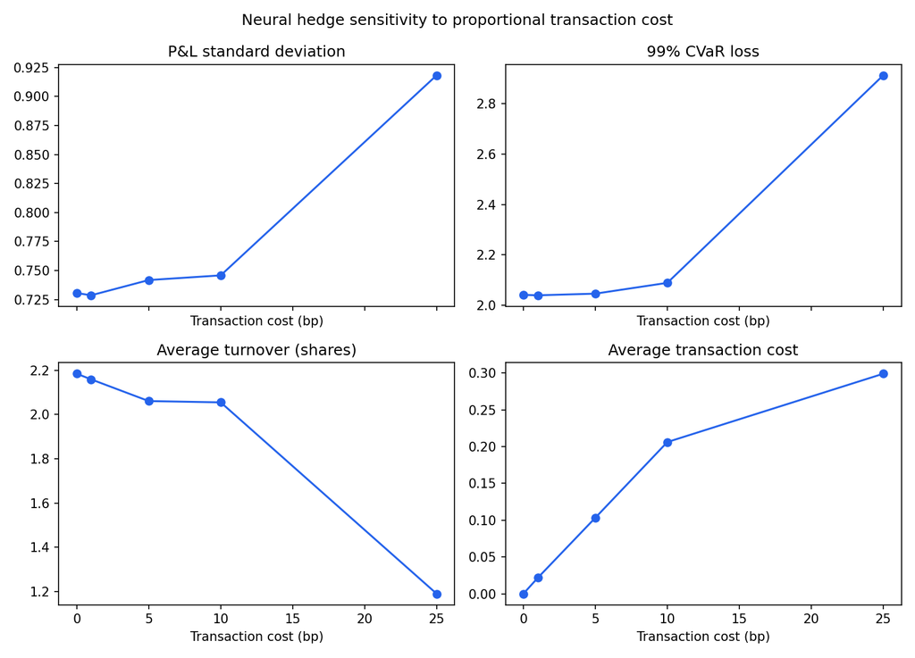

```python
display(sensitivity.round(4)); show_figure(sensitivity_figure(sensitivity))
```

## Risk-objective comparison

|  | objective | n_paths | mean_discounted_pnl_after_costs_including_premium | std_discounted_pnl_after_costs_including_premium | rmse_discounted_hedging_error | mae_discounted_hedging_error | median_discounted_pnl | minimum_discounted_pnl | maximum_discounted_pnl | pnl_quantile_01 | ... | average_turnover_shares | average_meaningful_trades | terminal_delta_mean | terminal_delta_std | terminal_delta_min | terminal_delta_q05 | terminal_delta_median | terminal_delta_q95 | terminal_delta_max | payoff_net_gain_correlation |
| --- | --- | --- | --- | --- | --- | --- | --- | --- | --- | --- | --- | --- | --- | --- | --- | --- | --- | --- | --- | --- | --- |
| 0 | mse | 20000 | -0.0741 | 0.7417 | 0.7454 | 0.5932 | -0.1271 | -3.1450 | 4.7311 | -1.7657 | ... | 2.0608 | 29.6346 | 0.6165 | 0.3632 | -0.1956 | 0.0338 | 0.6198 | 1.1744 | 1.2497 | 0.9865 |
| 1 | entropic | 20000 | -0.0056 | 1.0436 | 1.0436 | 0.8377 | 0.1793 | -3.8839 | 5.1563 | -2.5086 | ... | 1.6605 | 29.5070 | 0.6656 | 0.3605 | -0.1056 | 0.0990 | 0.6729 | 1.1927 | 1.2495 | 0.9821 |

2 rows × 30 columns

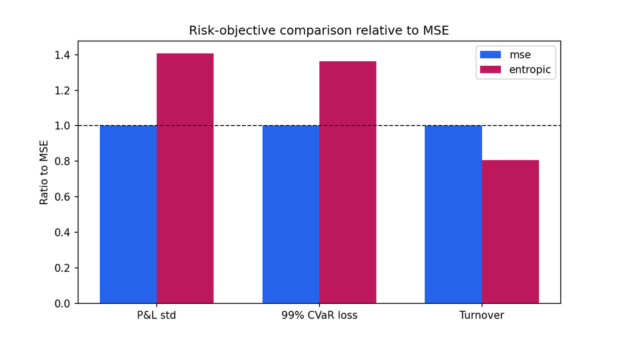

```python
display(risk_comparison.round(4)); show_figure(risk_objective_figure(risk_comparison))
```

## Sanity checks and limitations

```python
check_rows = [{'check': k, 'passed': v.get('passed'), 'details': str({x:y for x,y in v.items() if x != 'passed'})} for k,v in sanity.items() if isinstance(v, dict)]
display(pd.DataFrame(check_rows))
```

|  | check | passed | details |
| --- | --- | --- | --- |
| 0 | common_random_numbers | True | {'test_seed': 21210} |
| 1 | competent_hedge_reduces_dispersion | True | {'best_hedged_std': 0.4417760975884921, 'no_he... |
| 2 | near_frictionless_closer_to_bs_than_25bp | True | {'high_cost_bps': 25.0, 'high_rmse': 0.1155780... |
| 3 | separate_train_validation_test | True | {'test_seed': 21210, 'training_seed_range': [1... |
| 4 | tail_sample_size | True | {'expected_99pct_tail_observations': 200, 'tes... |
| 5 | turnover_generally_decreases_with_cost | True | {'high_turnover': 1.1899478435516357, 'low_tur... |

Constant-volatility GBM omits jumps, stochastic volatility, liquidity state, and model risk. Quick-profile tail estimates are intentionally labeled less stable than the full profile. No claim of superiority is made when its supporting sanity check fails.

## Phase 2 roadmap — Deep Pricing

Next, build a separately validated Black–Scholes/Monte Carlo label pipeline, then price-and-Greeks surrogates, differential learning, arbitrage-aware penalties, calibration tests, and inference-speed benchmarks. The executable specification is in `docs/ROADMAP_DEEP_PRICING.md`; Phase 2 code is deliberately out of scope here.